# IODS course project

# About the project

This is my first ever R Markdown document and I’m super excited about starting to use R Markdown. This has been created for the Uni of Helsinki course *Introduction to Open Data Science*, held in autumn 2017 in period 2. The course content sounds very useful for my research and I hope I will be able to start using the tools and skills straight away by doing some simple *data analysis and visualisation*. My **github repository** is https://github.com/karoliinaps/IODS-project.

# IODS course chapter 2 Regression analysis

**Data analysis**

**STEP 1** To perform linear regression analysis in R, the first step is to make sure that the data are in properly formatted in a dataframe. This has already been performed. Now the first step is to bring the data here so that I can start working on it. I have moved the csv file I created earlier in this working directory so I can read it directly. I will call the new dataframe object df:

```r
df <- read.csv("learning2014.csv")
```

Function str() shows the structure of the dataframe and tells that it has 166 observations od 7 variables and function head() shows the first six rows of the dataframe. This way I can be sure that the data is correctly imported.

```r
str(df)
```

```
## 'data.frame':    166 obs. of  7 variables:
##  $ gender  : Factor w/ 2 levels "F","M": 1 2 1 2 2 1 2 1 2 1 ...
##  $ Age     : int  53 55 49 53 49 38 50 37 37 42 ...
##  $ Attitude: int  37 31 25 35 37 38 35 29 38 21 ...
##  $ deep    : num  3.58 2.92 3.5 3.5 3.67 ...
##  $ stra    : num  3.38 2.75 3.62 3.12 3.62 ...
##  $ surf    : num  2.58 3.17 2.25 2.25 2.83 ...
##  $ Points  : int  25 12 24 10 22 21 21 31 24 26 ...
```

```r
head(df)
```

```
##   gender Age Attitude     deep  stra     surf Points
## 1      F  53       37 3.583333 3.375 2.583333     25
## 2      M  55       31 2.916667 2.750 3.166667     12
## 3      F  49       25 3.500000 3.625 2.250000     24
## 4      M  53       35 3.500000 3.125 2.250000     10
## 5      M  49       37 3.666667 3.625 2.833333     22
## 6      F  38       38 4.750000 3.625 2.416667     21
```

summary() function prints a summary of each variable.

```r
summary(df)
```

```
##  gender       Age           Attitude          deep            stra
##  F:110   Min.   :17.00   Min.   :14.00   Min.   :1.583   Min.   :1.250
##  M: 56   1st Qu.:21.00   1st Qu.:26.00   1st Qu.:3.333   1st Qu.:2.625
##          Median :22.00   Median :32.00   Median :3.667   Median :3.188
##          Mean   :25.51   Mean   :31.43   Mean   :3.680   Mean   :3.121
##          3rd Qu.:27.00   3rd Qu.:37.00   3rd Qu.:4.083   3rd Qu.:3.625
##          Max.   :55.00   Max.   :50.00   Max.   :4.917   Max.   :5.000
##       surf           Points
##  Min.   :1.583   Min.   : 7.00
##  1st Qu.:2.417   1st Qu.:19.00
##  Median :2.833   Median :23.00
##  Mean   :2.787   Mean   :22.72
##  3rd Qu.:3.167   3rd Qu.:27.75
##  Max.   :4.333   Max.   :33.00
```

**STEP2** To visually study the variables in the data set and see how they are correlated, I use GGally and ggplot2 R packages. First I install them using RStudio’s tool to install the packages and then I use the library() to load the the packages. Then I create the plot with ggpairs:

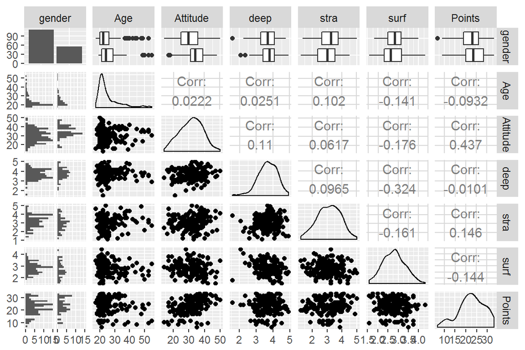

```r
library(GGally)
library(ggplot2)

# Here I create the plot matrix with ggpairs()
p <- ggpairs(df, mapping = aes(), lower = list(combo = wrap("facethist", bins = 20)))
p
```

**Linear regression model** assumes a linear relationship between the independent (explanatory) and dependent (target) variables. The goal in the model is to estimate the parameters alpha and beta(s), where alpha is a parameter for the intercept of the function, and the betas describe the relationship between the variables.

_ The statistical significance of the model parameters is tested with t-test and p-value. t-test is a statistical test which is used when we assume that the data is normally distributed. In the linear regression model, we can use the t-test to test whether the alpha and beta coefficients are statistically significantly different from zero. More often, however, the p-value is used to test the null hypothesis that the beta coefficient of the independent variable is zero, implying that there is no statistically significant relationship between the two variables. 5% significance level means that we have a 5% chance of wrongly rejecting the null hypothesis (beta=0). 5% is often used in regression analysis as the signifance level to conclude that the independent variable explains the dependent variable. _

Linear regression model in R is done with function lm() and summary() prints the summary of the model:

```r
names(df)
```

```
## [1] "gender"   "Age"      "Attitude" "deep"     "stra"     "surf"
## [7] "Points"
```

```r
df_lm <- lm(Points ~ Attitude + stra + Age, data=df)

summary(df_lm)
```

```
##
## Call:
## lm(formula = Points ~ Attitude + stra + Age, data = df)
##
## Residuals:
##      Min       1Q   Median       3Q      Max
## -18.1149  -3.2003   0.3303   3.4129  10.7599
##
## Coefficients:
##             Estimate Std. Error t value Pr(>|t|)
## (Intercept) 10.89543    2.64834   4.114 6.17e-05 ***
## Attitude     0.34808    0.05622   6.191 4.72e-09 ***
## stra         1.00371    0.53434   1.878   0.0621 .
## Age         -0.08822    0.05302  -1.664   0.0981 .
## ---
## Signif. codes:  0 '***' 0.001 '**' 0.01 '*' 0.05 '.' 0.1 ' ' 1
##
## Residual standard error: 5.26 on 162 degrees of freedom
## Multiple R-squared:  0.2182, Adjusted R-squared:  0.2037
## F-statistic: 15.07 on 3 and 162 DF,  p-value: 1.07e-08
```

The model results (beta coefficients) show that when one unit change in the attitude variable increases Point variable by 0.35, one unit change in the stra variable increases Point variable by 1 and one unit change in the age variable decreases Point variable by 0.08 units.

Only the intercept and Attitude are statistically significantly different from zero with 5% significance level, as can be seen in the p-value. In this model, stra and Age are statistically significantly different from zero with 10% significance level, which is sometimes accepted as a significance level. The explanatory power of the model is not very high, as the coefficient of determination (R-squared) is 0.2 so the independent variables only explain 0.2 of the variance of the dependent variable exam points.

In the next phase, I will run the model again but remove the independent variables which are not statistically significant with 5% signifance level, ie stra and Age:

```r
df_lm2 <- lm(Points ~ Attitude, data=df)

summary(df_lm2)
```

```
##
## Call:
## lm(formula = Points ~ Attitude, data = df)
##
## Residuals:
##      Min       1Q   Median       3Q      Max
## -16.9763  -3.2119   0.4339   4.1534  10.6645
##
## Coefficients:
##             Estimate Std. Error t value Pr(>|t|)
## (Intercept) 11.63715    1.83035   6.358 1.95e-09 ***
## Attitude     0.35255    0.05674   6.214 4.12e-09 ***
## ---
## Signif. codes:  0 '***' 0.001 '**' 0.01 '*' 0.05 '.' 0.1 ' ' 1
##
## Residual standard error: 5.32 on 164 degrees of freedom
## Multiple R-squared:  0.1906, Adjusted R-squared:  0.1856
## F-statistic: 38.61 on 1 and 164 DF,  p-value: 4.119e-09
```

Running the model with only Attitude as explanatory variable did not change the results much: The model results (beta coefficient) show that a one unit change in the attitude variable increases Point variable again by 0.35.

The explanatory power of the model is lower than in the original mode, as the coefficient of determination (R-squared) is 0.19 so the independent variables only explain 0.19 of the variance of the dependent variable exam points.

The residuals are slightly better normally distributed as the min of residuals is closer to the median than in the original model.

To analyse the assumptions described above related to the errors in the model, I plot Residuals vs Fitted values, Normal QQ-plot and Residuals vs Leverage figures which are used for model diagnostics.

**STEP5**

*The linear regression model assumes that there is unobservable - error - part of the model which is assumed to be normally distributed, the errors are not correlated with the fitted values of the model, the errors have constant variance and the size of a given error does not depend on the model variables.*

To study the first assumption on the normality of the errors, we can plot a Normal Q-Q plot. This plots and compares the quantiles of the error term to quantiles of a theoretical normal distribution and plots the points to y=x line.

To study the second assumption on no correlation between the errors and fitted values - the constant variance of the errors in other words, we plot the Residuals vs Fitted plot which shows the correlation between the two.

To study if single observations have impact on the model we plot the Residuals vs Leverage plot. The figures are plotted with the function plot():

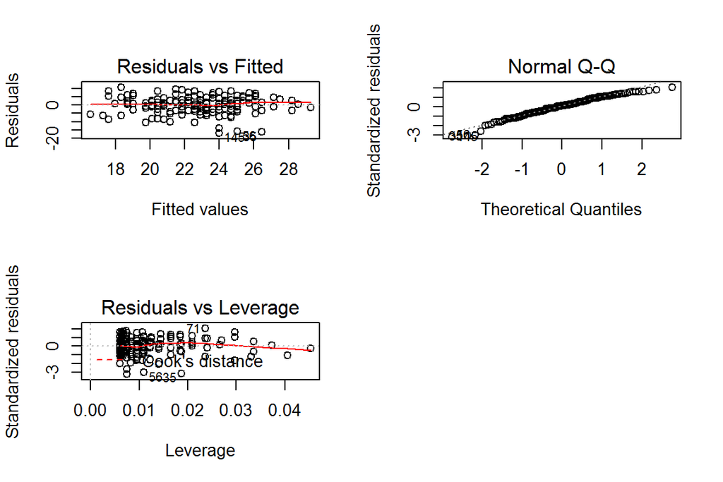

```r
par(mfrow = c(2,2))
plot(df_lm2, which = c(1,2,5))
```

The first correlation plot, Residuals vs Fitted, shows that there is no clear pattern in the correlation between the fitted variables and the error term, thereby not violating the assumption on the independence on the variance of the error from the fitted values.

As the residuals in the The Normal Q-Q are well aligned on the y=x line, we can conclude that the errors are normally distributed.

The residuals vs Leverage plot indicates the there are no **individual** observations which would have a high impact on the model.

We can conclude that the assumptions on the errors are satisfied and we can interpret the results of the regression model based on the linear regression model analysis performed earlier.

# IODS course chapter 3 LOGISTIC REGRESSION

First the data set is read into R:

```r
alc <- read.csv("alc.csv",  header=T)
```

The column names are:

```r
colnames(alc)
```

```
##  [1] "school"     "sex"        "age"        "address"    "famsize"
##  [6] "Pstatus"    "Medu"       "Fedu"       "Mjob"       "Fjob"
## [11] "reason"     "nursery"    "internet"   "guardian"   "traveltime"
## [16] "studytime"  "failures"   "schoolsup"  "famsup"     "paid"
## [21] "activities" "higher"     "romantic"   "famrel"     "freetime"
## [26] "goout"      "Dalc"       "Walc"       "health"     "absences"
## [31] "G1"         "G2"         "G3"         "alc_use"    "high_use"
```

This data approach student achievement in secondary education of two Portuguese schools. The data attributes include student grades, demographic, social and school related features) and it was collected by using school reports and questionnaires. Two datasets are provided regarding the performance in two distinct subjects: Mathematics (mat) and Portuguese language (por). In [Cortez and Silva, 2008], the two datasets were modeled under binary/five-level classification and regression tasks. Important note: the target attribute G3 has a strong correlation with attributes G2 and G1. This occurs because G3 is the final year grade (issued at the 3rd period), while G1 and G2 correspond to the 1st and 2nd period grades. It is more difficult to predict G3 without G2 and G1, but such prediction is much more useful (see paper source for more details).

The purpose of the analysis is to **study the relationships between high/low alcohol consumption and some of the other variables in the data**.

I choose the following variables to study the relationship: sex (student’s sex (binary: ‘F’ - female or ‘M’ - male)), age (student’s age (numeric: from 15 to 22)), failures (number of past class failures (numeric: n if 1<=n<3, else 4)) and health (current health status (numeric: from 1 - very bad to 5 - very good)). *My hypothesis is that sex and failures affect alcohol consumption, but age and health do not.*

**ANALYSIS** To make the analysis easier, I will create a new dataset alc2 which only contains the dependent and independent variables

```r
alc2 <- subset(alc, select=c(high_use, sex, age, failures, health))
library(magrittr)
library(dplyr)
```

```r
library(ggplot2)
library(tidyr)
```

To numerically and graphically explore the distributions of my chosen variables, I first have to access libraries tidyr, dplyr and ggplot2. I have done them using RStudios built-in tools.

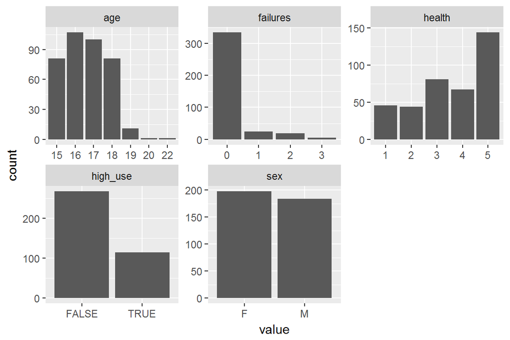

```r
gather(alc2) %>% ggplot(aes(value)) + facet_wrap("key", scales = "free") + geom_bar()
```

```r
alc2 %>% group_by(sex, high_use) %>% summarise(count = n(), mean_health = mean(health))
```

```
## # A tibble: 4 x 4
## # Groups:   sex [?]
##      sex high_use count mean_health
##   <fctr>    <lgl> <int>       <dbl>
## 1      F    FALSE   156    3.378205
## 2      F     TRUE    42    3.404762
## 3      M    FALSE   112    3.714286
## 4      M     TRUE    72    3.875000
```

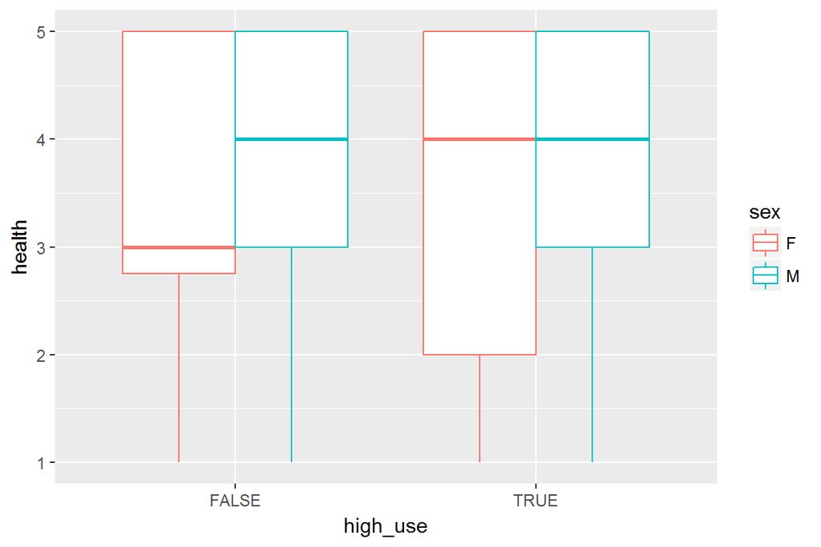

```r
g1 <- ggplot(alc2, aes(x = high_use, y = health, col =sex))
g1 + geom_boxplot() + ylab("health")
```

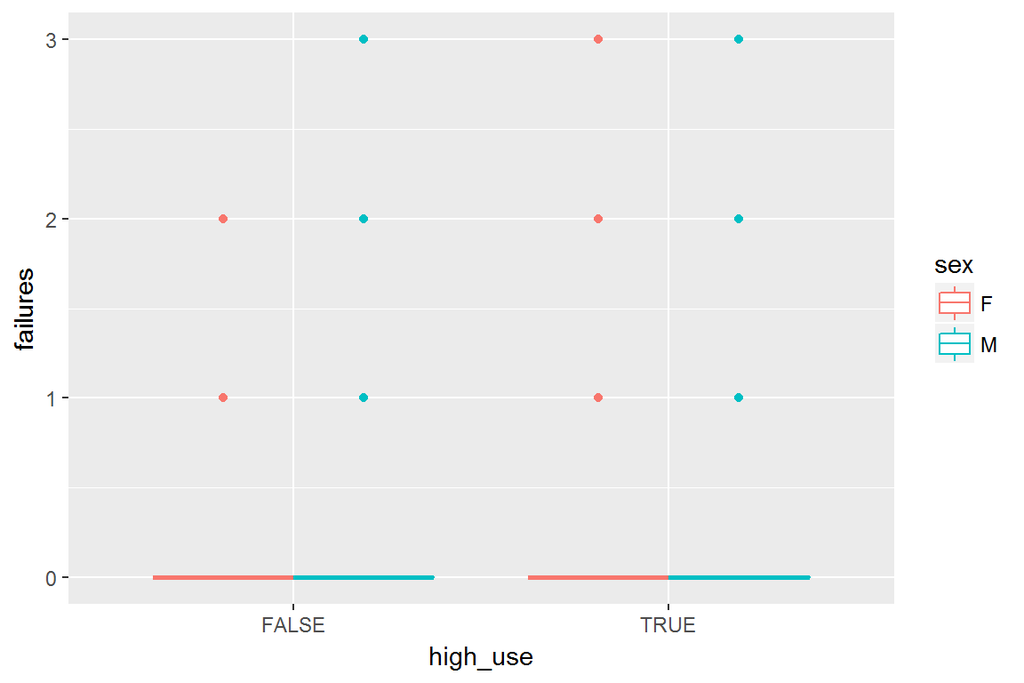

```r
g2 <- ggplot(alc2, aes(x = high_use, y = failures, col =sex))
g2 + geom_boxplot() + ylab("failures")
```

The plots do not really tell much about the distribution of this variable :)

```r
alc2 %>% group_by(sex, high_use) %>% summarise(count = n(), mean_health = mean(health))
```

```
## # A tibble: 4 x 4
## # Groups:   sex [?]
##      sex high_use count mean_health
##   <fctr>    <lgl> <int>       <dbl>
## 1      F    FALSE   156    3.378205
## 2      F     TRUE    42    3.404762
## 3      M    FALSE   112    3.714286
## 4      M     TRUE    72    3.875000
```

Mean health does not seem to differ much between alcohol consumption levels.

```r
alc2 %>% group_by(sex, high_use) %>% summarise(count = n(), mean_failures = mean(failures))
```

```
## # A tibble: 4 x 4
## # Groups:   sex [?]
##      sex high_use count mean_failures
##   <fctr>    <lgl> <int>         <dbl>
## 1      F    FALSE   156     0.1153846
## 2      F     TRUE    42     0.2857143
## 3      M    FALSE   112     0.1785714
## 4      M     TRUE    72     0.3750000
```

Average number of failures seems to dffer between different consumption levels.

**LOGISTIC REGRESSION**

```r
m <- glm(high_use ~ failures + sex + health + age, data = alc2, family = "binomial")
summary(m)
```

```
##
## Call:
## glm(formula = high_use ~ failures + sex + health + age, family = "binomial",
##     data = alc2)
##
## Deviance Residuals:
##     Min       1Q   Median       3Q      Max
## -1.5158  -0.8668  -0.6808   1.2772   1.9809
##
## Coefficients:
##             Estimate Std. Error z value Pr(>|z|)
## (Intercept) -4.62800    1.73918  -2.661 0.007790 **
## failures     0.41083    0.19215   2.138 0.032514 *
## sexM         0.83019    0.23587   3.520 0.000432 ***
## health       0.04874    0.08606   0.566 0.571165
## age          0.18458    0.10078   1.832 0.067023 .
## ---
## Signif. codes:  0 '***' 0.001 '**' 0.01 '*' 0.05 '.' 0.1 ' ' 1
##
## (Dispersion parameter for binomial family taken to be 1)
##
##     Null deviance: 465.68  on 381  degrees of freedom
## Residual deviance: 440.37  on 377  degrees of freedom
## AIC: 450.37
##
## Number of Fisher Scoring iterations: 4
```

```r
coef(m)
```

```
## (Intercept)    failures        sexM      health         age
## -4.62800180  0.41083200  0.83019261  0.04874039  0.18457895
```

```r
OR <- coef(m) %>% exp
CI <- confint (m) %>% exp
cbind(OR, CI)
```

```
##                      OR        2.5 %    97.5 %
## (Intercept) 0.009774271 0.0003058166 0.2838926
## failures    1.508071974 1.0369791732 2.2157942
## sexM        2.293760488 1.4502799705 3.6621000
## health      1.049947736 0.8881190252 1.2454979
## age         1.202711929 0.9885625901 1.4687473
```

We see that failures and sex are statistically significant variables explaining alcohol consumption so this confirms my hypothesis.

And now I ran out of time :(